# Problema 4 - Checkpoint 1

Marcos Antonio Silva Nascimento (marcos.nascimento@ccc.ufcg.edu.br)

11 de julho de 2017

Parte 1: você e um problema pequeno Dados de opiniões sobre filmes

Para essa parte do problema usaremos dados sobre avaliações de filmes: http://grouplens.org/datasets/movielens/latest/ (Links para um site externo)Links para um site externo . Para essa parte do problema, usaremos o dataset small. Para a parte onde você escolhe a pergunta e conduz a investigação você escolhe qual dos datasets usar.

Independente do dado que você usar, lembre que temos aqui apenas uma amostra das opiniões de todas as pessoas. Este problema trata com estimarmos a opinião que a audiência de um filme tem a partir dessa amostra.

O que fazer

Temos duas perguntas de pesquisa. Responda ambas em um relatório rmarkdown. Lembre de escrever uma frase com o vocabulário do domínio do problema explicando seu achado.

Escolha uma trilogia (ou uma n-logia com n > 3) e avalie para qual dos episódios da trilogia há melhor avaliação e para qual há mais variação nas notas atribuídas ao filme. (Exemplos: Poderoso Chefão, Star Wars, Matrix, etc.)

Normalmente os filmes têm vários gêneros. Existe uma relação entre em quantos gêneros os filmes se encaixam e a avaliação que os filmes recebem? Mais especificamente: se consideramos a os filmes com 1, 2, 3 … gêneros, existe alguma quantidade de gêneros num mesmo filme que em geral recebe avaliações melhores? Caso exista, estime a diferença entre essa combinação e filmes com apenas um gênero. (Repare que você terá que escolher que medida você comparará: média, mediana, etc.)

Lembre: não comece sua análise sem antes fazer um descritivo dos dados. Mostre esse descritivo ao leitor. Lide com outliers.

```r
movies = read_csv("../dados/movies.csv")
ratings = read_csv("../dados/ratings.csv")
genres = read_csv("../dados/movie-genre.csv")
genres = genres %>%
  group_by(movieId, title) %>%
  summarise(nGenre = n())
```

# Mais filmes! Como se comportam as avaliações dos filmes do site GroupLens?

## Quais os episódios de ouro de Resident Evil?

O suscesso dos filmes de Resident Evil já não é mais nenhuma novidade. Isso fica cada vez mais evidente pelo simples motivo de observar o empenho e a motivação dos diretores em inovarem e lançarem novos filmes desde o seu aparecimento no mundo dos jogos. Vamos estimar, a partir de uma amostra de opiniões do filme, os intervalos de valores que delineam a avaliação de cada filme. Utilizaremos os dados cedidos pelo site [GroupLens](http://grouplens.org/datasets/movielens/latest/).

```r
re_movies = movies %>%
  filter(grepl("Resident Evil", title))

dados = merge(re_movies, ratings, by="movieId")

dados = merge(dados, genres, by=c("movieId","title")) %>%
  subset(select = -c(userId, timestamp, genres))

dados = dados %>%
  mutate(title = replace(title,
                         which(title == "Resident Evil: Apocalypse (2004)"),
                         "Apocalypse (2004)")) %>%
  mutate(title = replace(title,
                         which(title == "Resident Evil: Extinction (2007)"),
                         "Extinction (2007)")) %>%
  mutate(title = replace(title,
                         which(title == "Resident Evil: Afterlife (2010)"),
                         "Afterlife (2010)")) %>%
  mutate(title = replace(title,
                         which(title == "Resident Evil: Retribution (2012)"),
                         "Retribution (2012)"))
```

### Descritivo e decisões sobre filtrar dados ou variáveis

Curiosamente o conjunto de dados não contém muitas avaliações para alguns filmes de Resident Evil. Por exemplo, os filmes Afterlife (2010) e Retribution (2012) são os que contém menos avaliações. Vejamos o gráfico abaixo.

```r
ggplotly(dados %>%
    ggplot(aes(x = title, y = rating, color = title)) +
    geom_jitter(width = .1) +
  ggtitle("Distribuição da avaliação dos filmes") +
  ylab("Avaliação") +
  xlab("Filme") +
  theme(legend.position="none",
        plot.title = element_text(hjust = 0.5)))
```

[interactive chart not shown]

Podemos ainda observar valores estranhos, curiosamente, Apocalypse possui a pior e também a maior avaliação de todos os episódios. Utilizar a média como estimativa de comparação entre os episódios não seria prudente e até mesmo injusto porque a mesma estaria sendo inlfuenciada por esses valores discrepantes.

Um ponto importante é que: como iremos utilizar o conceito de intervalos de confiança para estimar a avaliação de um filme então é importante que o filme possua um conjunto significativo de avaliações. Por este motivo, os únicos filmes submetidos a análise serão: Apocalypse (2004), Extinction (2007) e Resident Evil (2002).

```r
dados = dados %>%
  filter(!(title %in% c("Afterlife (2010)",
                        "Retribution (2012)")))
```

### Qual o episódio mais bem avaliado?

Antes de mais nada precisamos escolher a métrica de comparação, a métrica de comparação adotada será a mediana de avaliação por não ser afetada ou enviesada por valores extremos ou outliers.

```r
ggplotly(dados %>%
    ggplot(aes(x = title, y = rating, color = title)) +
    geom_jitter(width = .1) +
  geom_boxplot() +
  ggtitle("Distribuição da avaliação dos filmes") +
  ylab("Avaliação") +
  xlab("Filme") +
  theme(legend.position="none",
        plot.title = element_text(hjust = 0.5)))
```

[interactive chart not shown]

Os gráficos acima mostram vários valores calculados a partir do conjunto de avaliações de cada filme. Os quadrados ou box’s representam a distância interquartil (representam 50% das avaliações de cada episódio). As retas que cortam cada box são os valores de avaliação mediana para cada episódio. Observando o gráfico de box-plot, fica claro que tanto Extinction quanto Resident Evil ficam empatados. Ambos os episódios possuem a mediana de avaliação igual à 3.

### Qual a expectativa de avaliação para cada um dos episódios de Resident Evil? Para qual deles há melhor avaliação? E para qual há mais variação nas avaliações?

```r
bootstrap.mediana.extinction =  bootstrap(
  (dados %>% filter(title == "Extinction (2007)"))$rating, median, R = 1000)

mediana.resident.extinction = CI.percentile(bootstrap.mediana.extinction,
                                      probs = c(.025, .975))

bootstrap.mediana.apocalypse =  bootstrap(
  (dados %>% filter(title == "Apocalypse (2004)"))$rating, median, R = 1000)

mediana.resident.apocalypse = CI.percentile(bootstrap.mediana.apocalypse,
                                      probs = c(.025, .975))

bootstrap.mediana.resident.evil =  bootstrap(
  (dados %>% filter(title == "Resident Evil (2002)"))$rating, median, R = 1000)

mediana.resident.evil = CI.percentile(bootstrap.mediana.resident.evil,
                                      probs = c(.025, .975))

medianas <- data.frame(
  rbind(
    c("Resident Evil (2002)", mediana.resident.evil),
    c("Apocalypse (2004)", mediana.resident.apocalypse),
    c("Extinction (2007)", mediana.resident.extinction)
  )
)
names(medianas) = c("title", "inferiorLimit", "upperLimit")
```

Qual seria a expectativa de mediana de avaliação para cada um dos episódios mostrados acima?

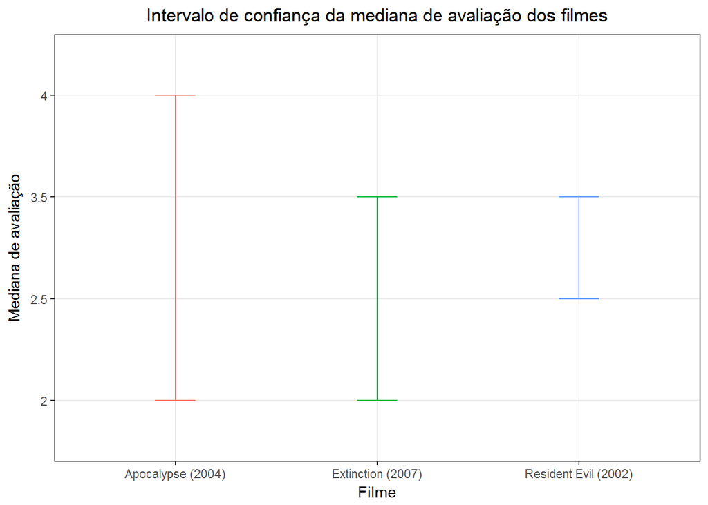

```r
medianas %>%
  ggplot( aes(x = title,
              ymin = inferiorLimit,
              ymax = upperLimit,
              color = title)) +
  geom_errorbar(width = .2) +
  ggtitle("Intervalo de confiança da mediana de avaliação dos filmes") +
  ylab("Mediana de avaliação") +
  xlab("Filme") +
  theme(legend.position="none",
        plot.title = element_text(hjust = 0.5))
```

A expectativa de avaliação mediana pode ser observada logo acima. O episódio Resident Evil, por exemplo, pode chegar a obter tanto a mediana de avaliação 2.5 quanto 3.5. Visivelmente o episódio Apocalypse seria o único que poderia obter a maior mediana de avaliação (entre 3.5 e 4).

Observando os intervalos de confiança para a mediana de avaliação de cada um dos episódios nada podemos concluir quanto qual dos episódios será o melhor ou maior avaliado. Quanto a variação podemos concluir que o episódio que mais pode variar em termos de mediana será o filme Apocalypse (2004).

## Existe uma relação entre a quantidade de gêneros de um filme e a avaliação que este recebe?

Será que existente relacionamento entre a quantidade de gêneros que cada filme possui e sua avaliação? Antes de mais nada foi necessário transformar os dados cedidos pelo site para um formato diferente. Uma nova tabela contém os filmes separados por um único gênero. Isso irá facilitar a contagem e associação da quantidade de gênero a cada filme.

### Decisões sobre filtrar dados ou variáveis

Curiosamente o conjunto de dados não contém muitas avaliações para certas quantidades de gêneros. Por exemplo, apesar de existirem filmes associados a 8 e a 10 gêneros cinematográficos, há poucas avaliações para estes filmes (1 avaliação) e portanto estes dados serão filtrados porque eles não são interessantes para serem aplicados aos intervalo de confiança.

```r
dados2 = merge(genres, ratings, by="movieId") %>%
  subset(select = -c(userId, timestamp))

bootf <- function(x) {
    b =  bootstrap(x$rating, median, R = 1000)
    m = CI.percentile(b, probs = c(.025, .975))
    newstuff = rbind(m) %>%
      data.frame()
    return(newstuff)
}

dados3 = dados2 %>%
  filter(nGenre <= 7) %>%
  group_by(nGenre) %>%
  do(bootf(.)) %>%
  setNames(c("nGenre","rating_lwr","rating_upr"))
```

### Qual a expectativa de avaliação para cada quantidade de gêneros? Para qual das quantidades há melhor avaliação? E para qual há mais variação nas avaliações?

Antes de mais nada precisamos escolher a métrica de comparação, a métrica de comparação adotada será a mediana de avaliação por não ser afetada ou enviesada por valores extremos ou outliers. Os intervalos de confiança foram calculados para a mediana de avaliação de cada quantidade de gêneros de um filme.

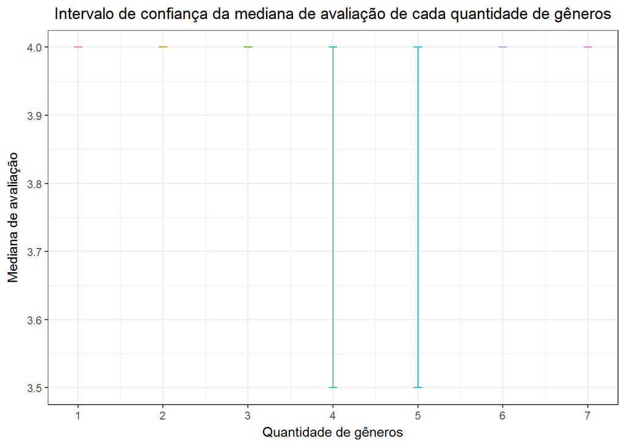

```r
dados3 %>%
  ggplot(aes(x = nGenre,
             ymin = rating_lwr,
             ymax = rating_upr,
             color=as.character(nGenre))) +
  geom_errorbar(width = .1) +
  scale_x_continuous(breaks = seq(1,7,1)) +
  labs(x="Quantidade de gêneros", y="Mediana de avaliação") +
  ggtitle("Intervalo de confiança da mediana de avaliação de cada quantidade de gêneros")+
  theme(legend.position="none",
        plot.title = element_text(hjust = 0.5))
```

A expectativa de avaliação para cada quantidade pode ser observada logo acima. Os filmes com quantidade de gêneros igual a 4 e 5, por exemplo, podem chegar a obter a mediana de avaliação entre 3.5 e 4, enquanto os filmes com quantidade 1, 2, 3, 6 e 7 podem atingir a mediana de avaliação mais alta (igual a 4).

Observando os intervalos de confiança para a mediana de avaliação de cada quantidade de gênero nada podemos concluir quanto qual delas será a melhor ou maior avaliada, evidentemente, não podemos observar a existência de uma relação de quanto maior a quantidade de gênero melhor a avaliação.

Quanto a variação podemos concluir que os filmes com 4 e 5 gêneros cinematográficos mais pode variar em termos de mediana de avaliação.